# Панельные данные

Загрузим необходимые библиотеки.

```r
library(plm) # Пакет для работы с панельными данными
library(lmtest) # Пакет для оценки регрессий и ковариационных матриц параметров
library(skimr) # Для красивого summary
library(car) # Для некоторых графиков
library(gplots) # Для графиков гетерогенности
library(rio) # Пакет для обработки данных
library(tidyverse) # Ещё один пакет для обработки данных
library(car) # Пакет, содержащий простые линейные модели
```

Загрузим данные и преобразуем нужные переменные в факторные. В данном разделе все визуализации будут построены на подмножестве данных из шести наблюдений. Это позволит сделать их более читаемыми в формате книги. Все модели будут оценены на всём массиве данных.

```r
panel = import('lwage_panel_small.csv')
panel = mutate(panel, black = factor(black), id = factor(id))
```

Изобразим наши панельные данные на диаграмме рассеяния. Дополнимельно установим параметр сглаживания, чтобы получить кривые временных рядов.

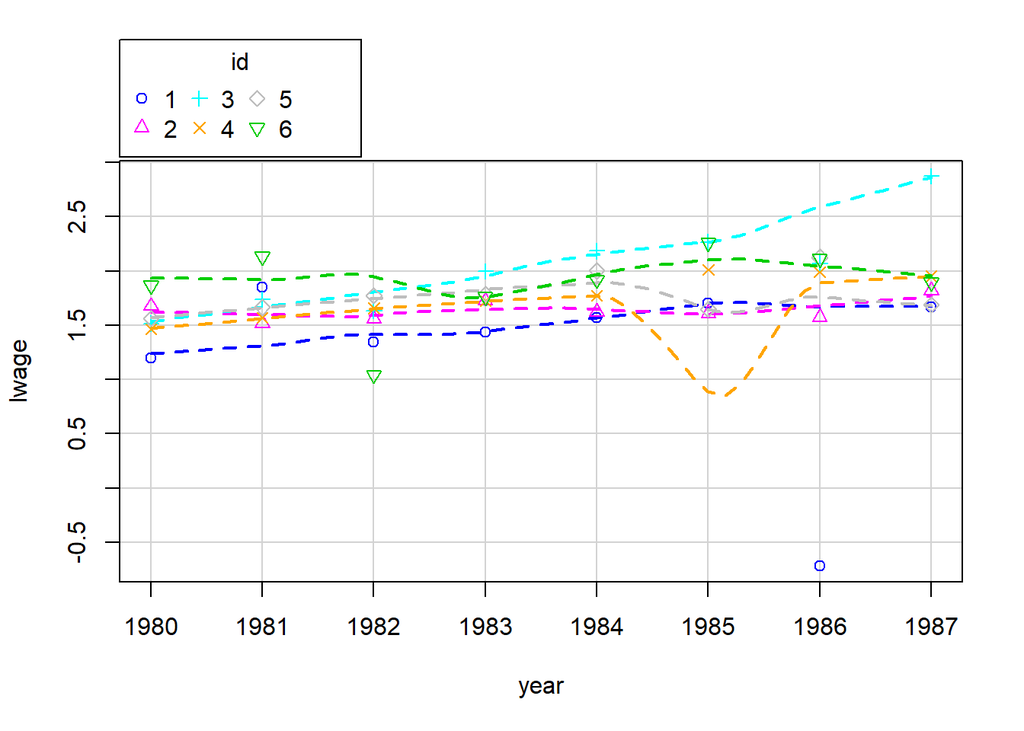

```r
scatterplot(lwage ~ year|id, boxplots=F, smooth=TRUE, regLine=FALSE, data=panel)
```

Для получения графиков на различных плитках можно использовать coplot.

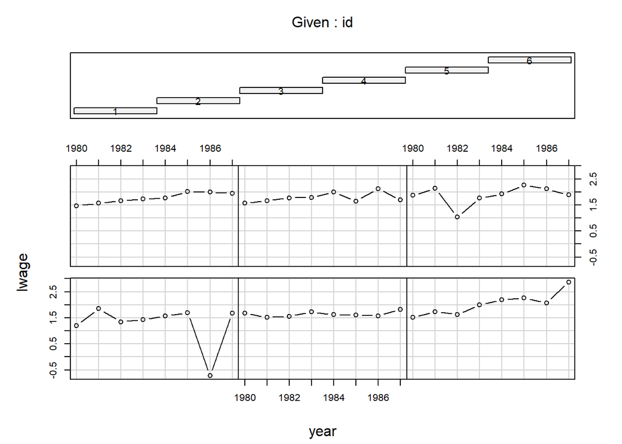

```r
coplot(lwage ~ year|id, type = 'b', data = panel)
```

Сгруппировать можно по разным признакам. Например, в зависимости от расы индивидов.

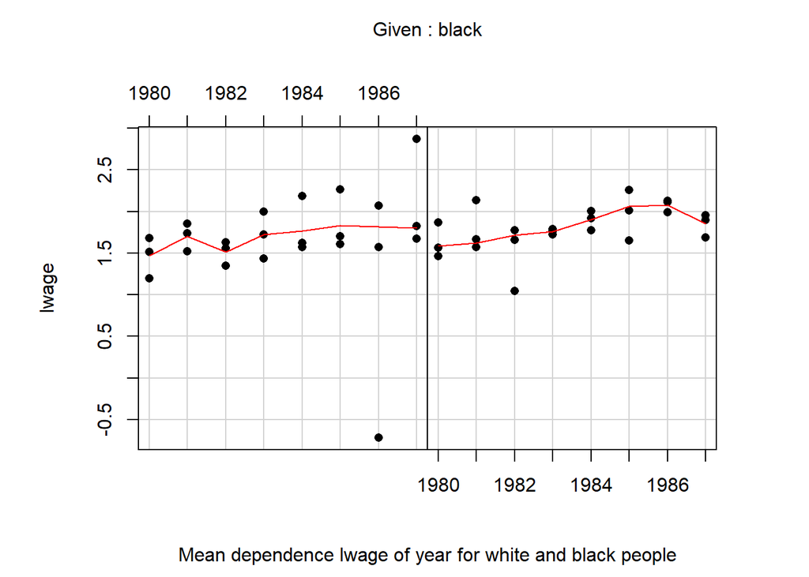

```r
panel$year = factor(panel$year)
coplot(lwage ~ year|black, type="l", data=panel, panel = function(x, y, ...) panel.smooth(x, y, span = 0.3, ...), pch = 16, show.given = F, xlab = "Mean dependence lwage of year for white and black people")
```

Импортируем основной датасет.

```r
Panel = import('lwage_panel_large.csv')
```

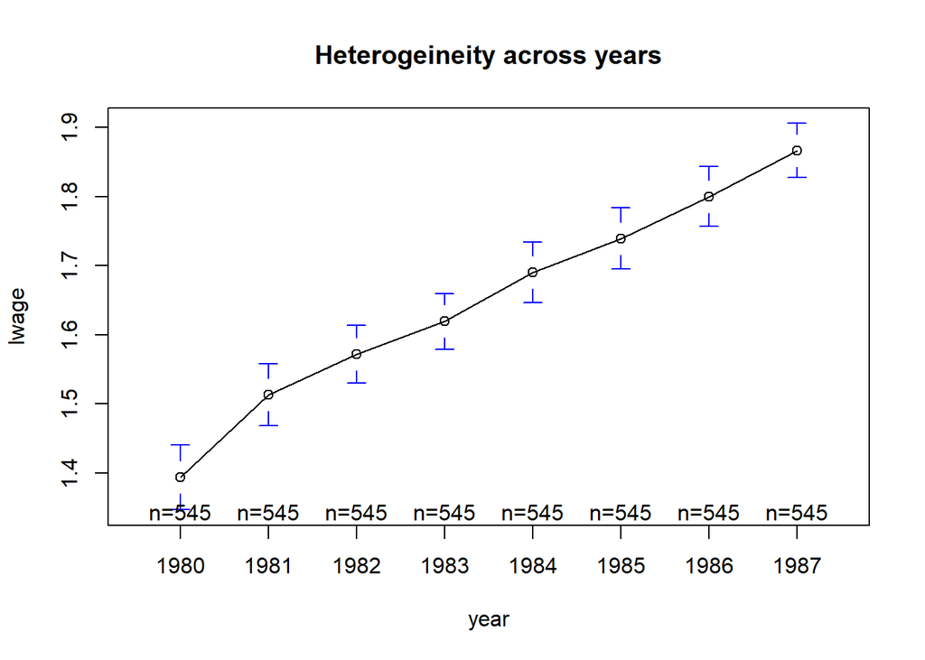

```r
plotmeans(lwage ~ year, main="Heterogeineity across years", data=Panel)
```

Модель панельных данных будет выглядеть следующим образом:

$$\begin{equation}
y_{i t}=\alpha+x_{i t}^{\prime} \beta+z_{i}^{\prime} \gamma+c_{i}+u_{i t}
\end{equation}$$

где $\alpha$ – константа, $c_{i}$ - индивидуальные эффекты индивидов, а $z_i$ – независимые от времени переменные. Следовательно, матрица $X$ - матрица зависимых от времени регрессов, $Z$ - матрица независимых от времени регрессоров. Дополнительно обозначим как $l_n$ вектор из единиц.

Оценим простую модель с фиксированными эффектами через within-оценку. Вычитая $\overline{y}_{i}=1 / T \sum_{t} y_{i t}$ из исходной модели, получим within-модель:

$$\begin{equation}
\ddot{y}_{i t}=\ddot{x}_{i t}^{\prime} \beta+\ddot{u}_{i t}
\end{equation}$$

где $\ddot{y}_{i t}=y_{i t}-\overline{y}_{i}, \ddot{x}_{i t k}=x_{i t k}-\overline{x}_{i k}$ and $\ddot{u}_{i t}=u_{i t}-\overline{u}_{i}$. Следует заметить, что константа $\alpha$, индивидуальные эффекты $c_i$ и инвариантные ко времени регрессоры $z_i$ исчезают из модели.

$$\begin{equation}
\widehat{\beta}_{F E}=\left(\ddot{X}^{\prime} \ddot{X}\right)^{-1} \ddot{X}^{\prime} \ddot{y}
\end{equation}$$

```r
ffe = plm(lwage ~ hours, model="within", data = Panel)
summary(ffe)
```

```
Oneway (individual) effect Within Model

Call:
plm(formula = lwage ~ hours, data = Panel, model = "within")

Balanced Panel: n = 545, T = 8, N = 4360

Residuals:
     Min.   1st Qu.    Median   3rd Qu.      Max.
-4.116091 -0.136963  0.015755  0.182507  1.555059

Coefficients:
         Estimate  Std. Error t-value Pr(>|t|)
hours -5.5854e-07  1.4013e-05 -0.0399   0.9682

Total Sum of Squares:    572.05
Residual Sum of Squares: 572.05
R-Squared:      4.1656e-07
Adj. R-Squared: -0.14289
F-statistic: 0.00158875 on 1 and 3814 DF, p-value: 0.96821
```

Проверим значимость коэффициентов, используя ковариационную матрицу ошибок Хубера - Уайта.

```r
coeftest(ffe, vcov=vcovHC(ffe, cluster="group"))
```

```
t test of coefficients:

         Estimate  Std. Error t value Pr(>|t|)
hours -5.5854e-07  2.5051e-05 -0.0223   0.9822
```

Оценим модель со случайными эффектами, используя достижимый обобщённый МНК (FGLS).

$$\begin{equation}
\left(\begin{array}{c}{\widehat{\alpha}_{R E}} \\ {\widehat{\beta}_{R E}} \\ {\widehat{\gamma}_{R E}}\end{array}\right)=\left(W^{\prime} \widehat{\Omega}_{v}^{-1} W\right)^{-1} W^{\prime} \widehat{\Omega}_{v}^{-1} y
\end{equation}$$

где

$W=\left[\iota_{N T} X Z\right] \text { и } \iota_{N T} \text { это вектор из единиц размерности } N T \times 1$

```r
fre = plm(lwage ~ hours, model="random", data = Panel)
summary(fre)
```

```
Oneway (individual) effect Random Effect Model
   (Swamy-Arora's transformation)

Call:
plm(formula = lwage ~ hours, data = Panel, model = "random")

Balanced Panel: n = 545, T = 8, N = 4360

Effects:
                 var std.dev share
idiosyncratic 0.1500  0.3873 0.528
individual    0.1341  0.3663 0.472
theta: 0.6498

Residuals:
     Min.   1st Qu.    Median   3rd Qu.      Max.
-4.506028 -0.164365  0.028671  0.218928  1.605623

Coefficients:
              Estimate Std. Error z-value Pr(>|z|)
(Intercept) 1.6459e+00 3.3705e-02 48.8332   <2e-16 ***
hours       1.4611e-06 1.3348e-05  0.1095   0.9128
---
Signif. codes:  0 '***' 0.001 '**' 0.01 '*' 0.05 '.' 0.1 ' ' 1

Total Sum of Squares:    653.53
Residual Sum of Squares: 653.53
R-Squared:      2.7494e-06
Adj. R-Squared: -0.00022671
Chisq: 0.0119818 on 1 DF, p-value: 0.91284
```

Проверим значимость коэффициентов, используя ковариационную матрицу ошибок Хубера - Уайта.

```r
coeftest(fre, vcov=vcovHC(ffe, cluster="group"))
```

```
t test of coefficients:

        Estimate Std. Error t value Pr(>|t|)
hours 1.4611e-06 2.5051e-05  0.0583   0.9535
```

Проведём тест Хаусмана

```r
phtest(ffe, fre)
```

```
    Hausman Test

data:  lwage ~ hours
chisq = 0.22438, df = 1, p-value = 0.6357
alternative hypothesis: one model is inconsistent
```

Построим FD-оценку.

$$\begin{equation}
\dot{y}_{i t}=\dot{x}_{i t}^{\prime} \beta+\dot{u}_{i t}
\end{equation}$$

$\dot{y}_{i t}=y_{i t}-y_{i, t-1}, \dot{x}_{i t}=x_{i t}-x_{i, t-1}$ и $\dot{u}_{i t}=u_{i t}-u_{i, t-1}$

```r
fd = plm(lwage ~ hours - 1, model="fd", data = Panel)
summary(fd)
```

[output not shown]

Построим LS-оценку с дамми-переменными по каждому индивиду (LSDV). Видим, что численно её результаты идентичны withih-регрессии, как и должно быть.

```r
lsdv = lm(lwage ~ hours + factor(id) - 1, data=Panel)
summary(lsdv)
```

```
Call:
lm(formula = lwage ~ hours + factor(id) - 1, data = Panel)

Residuals:
    Min      1Q  Median      3Q     Max
-4.1161 -0.1370  0.0158  0.1825  1.5551

Coefficients:
                Estimate Std. Error t value Pr(>|t|)
hours         -5.585e-07  1.401e-05  -0.040 0.968208
factor(id)1    1.257e+00  1.425e-01   8.825  < 2e-16 ***
factor(id)2    1.639e+00  1.413e-01  11.597  < 2e-16 ***
factor(id)3    2.036e+00  1.408e-01  14.455  < 2e-16 ***
factor(id)4    1.775e+00  1.404e-01  12.639  < 2e-16 ***
factor(id)5    2.056e+00  1.401e-01  14.680  < 2e-16 ***
factor(id)6    1.435e+00  1.424e-01  10.076  < 2e-16 ***
factor(id)7    1.996e+00  1.418e-01  14.077  < 2e-16 ***
factor(id)8    1.065e+00  1.434e-01   7.426 1.37e-13 ***
factor(id)9    1.474e+00  1.398e-01  10.537  < 2e-16 ***
factor(id)10   1.395e+00  1.394e-01  10.005  < 2e-16 ***
factor(id)11   1.385e+00  1.378e-01  10.052  < 2e-16 ***
factor(id)12   2.193e+00  1.396e-01  15.711  < 2e-16 ***
factor(id)13   1.840e+00  1.404e-01  13.103  < 2e-16 ***
factor(id)14   2.060e+00  1.413e-01  14.581  < 2e-16 ***
factor(id)15   2.455e+00  1.405e-01  17.468  < 2e-16 ***
factor(id)16   1.675e+00  1.400e-01  11.963  < 2e-16 ***
factor(id)17   1.697e+00  1.411e-01  12.031  < 2e-16 ***
factor(id)18   2.033e+00  1.398e-01  14.544  < 2e-16 ***
factor(id)19   2.214e+00  1.425e-01  15.533  < 2e-16 ***
factor(id)20   1.525e+00  1.400e-01  10.896  < 2e-16 ***
factor(id)21   1.726e+00  1.401e-01  12.321  < 2e-16 ***
factor(id)22   1.769e+00  1.400e-01  12.635  < 2e-16 ***
factor(id)23   2.077e+00  1.408e-01  14.754  < 2e-16 ***
factor(id)24   2.368e+00  1.400e-01  16.919  < 2e-16 ***
factor(id)25   1.311e+00  1.443e-01   9.085  < 2e-16 ***
factor(id)26   1.700e+00  1.399e-01  12.153  < 2e-16 ***
factor(id)27   2.284e+00  1.409e-01  16.214  < 2e-16 ***
factor(id)28   1.411e+00  1.411e-01  10.000  < 2e-16 ***
factor(id)29   7.640e-01  1.412e-01   5.409 6.71e-08 ***
factor(id)30   1.950e+00  1.403e-01  13.895  < 2e-16 ***
```

[output cut: 506 more lines]

```
factor(id)537  1.803e+00  1.417e-01  12.723  < 2e-16 ***
factor(id)538  1.284e+00  1.408e-01   9.116  < 2e-16 ***
factor(id)539  2.039e+00  1.405e-01  14.518  < 2e-16 ***
factor(id)540  1.617e+00  1.391e-01  11.629  < 2e-16 ***
factor(id)541  1.655e+00  1.390e-01  11.910  < 2e-16 ***
factor(id)542  2.179e+00  1.399e-01  15.582  < 2e-16 ***
factor(id)543  1.317e+00  1.418e-01   9.289  < 2e-16 ***
factor(id)544  2.172e+00  1.399e-01  15.531  < 2e-16 ***
factor(id)545  1.383e+00  1.405e-01   9.849  < 2e-16 ***
---
Signif. codes:  0 '***' 0.001 '**' 0.01 '*' 0.05 '.' 0.1 ' ' 1

Residual standard error: 0.3873 on 3814 degrees of freedom
Multiple R-squared:  0.9563,    Adjusted R-squared:  0.9501
F-statistic: 152.9 on 546 and 3814 DF,  p-value: < 2.2e-16
```

Построим оценку Pooled OLS. Проверим значимость коэффициентов, используя ковариационную матрицу ошибок Хубера - Уайта. Визуализируем игнорирование этой моделью гетерогенного эффекта.

```r
fpo = plm(lwage ~ hours, model="pooling",data = Panel)
coeftest(fpo, vcov=vcovHC(fpo, cluster="group"))
```

```
t test of coefficients:

              Estimate Std. Error t value Pr(>|t|)
(Intercept) 1.6286e+00 6.2980e-02  25.860   <2e-16 ***
hours       9.3560e-06 2.7040e-05   0.346   0.7294
---
Signif. codes:  0 '***' 0.001 '**' 0.01 '*' 0.05 '.' 0.1 ' ' 1
```

```r
summary(fpo)
```

```
Pooling Model

Call:
plm(formula = lwage ~ hours, data = Panel, model = "pooling")

Balanced Panel: n = 545, T = 8, N = 4360

Residuals:
     Min.   1st Qu.    Median   3rd Qu.      Max.
-5.226250 -0.297525  0.021354  0.342911  2.414420

Coefficients:
              Estimate Std. Error t-value Pr(>|t|)
(Intercept) 1.6286e+00 3.2240e-02 50.5170   <2e-16 ***
hours       9.3560e-06 1.4245e-05  0.6568   0.5113
---
Signif. codes:  0 '***' 0.001 '**' 0.01 '*' 0.05 '.' 0.1 ' ' 1

Total Sum of Squares:    1236.5
Residual Sum of Squares: 1236.4
R-Squared:      9.8978e-05
Adj. R-Squared: -0.00013046
F-statistic: 0.431389 on 1 and 4358 DF, p-value: 0.51134
```

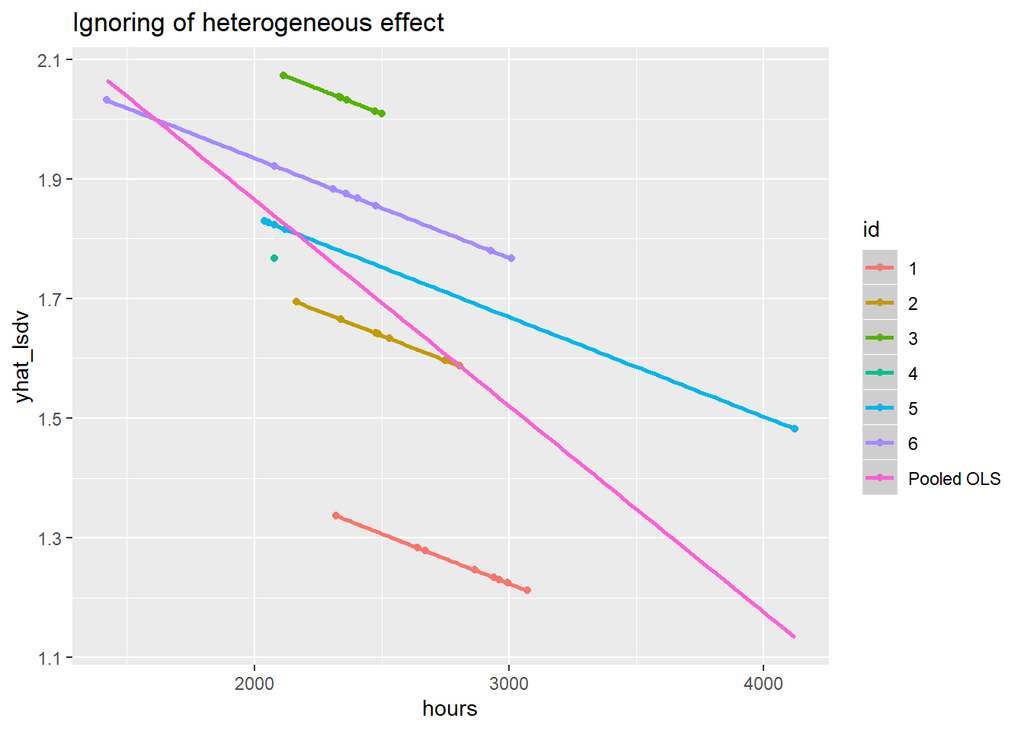

```r
panel = import('lwage_panel_small.csv')
panel$black = factor(panel$black)
panel$id = factor(panel$id)

lsdv_small = lm(lwage ~ hours + factor(id) - 1, data=panel)
yhat_lsdv <- lsdv_small$fitted.values


library(ggplot2)
g <- ggplot(panel, aes(hours, yhat_lsdv, col = id))
g + geom_point() +
  geom_smooth(aes(group = id, col = id), method = 'lm') +
  geom_smooth(aes(col = 'Pooled OLS'),method = 'lm', se = F) +
  labs(title = 'Ignoring of heterogeneous effect')
```

Теперь то же самое в Stata

Для начала подгрузим данные и посмотрим на них. Сперва визуализируем малый датасет.

```stata
use lwage_panel_small
summarize
```

```
    Variable |       Obs        Mean
> Std. Dev.       Min        Max
-------------+--------------------------
> ------------------------------
          nr |        48    364.6667
> 390.3276         13        910
        year |        48      1983.5
> 2.315535       1980       1987
       black |        48          .5
> .5052912          0          1
       exper |        48    5.833333
> 2.636353          1         11
        hisp |        48           0
>        0          0          0
-------------+--------------------------
> ------------------------------
       hours |        48    2407.875
> 425.1116       1420       4120
     married |        48       .1875
> .3944428          0          1
        educ |        48          13
>  .825137         12         14
       union |        48        .125
> .3342187          0          1
       lwage |        48    1.724878
> .4719456  -.7202626   2.873161
-------------+--------------------------
> ------------------------------
     expersq |        48    40.83333
>   31.933          1        121
  occupation |        48    4.083333
> 2.359529          1          9
          id |        48         3.5
> 1.725898          1          6
```

```stata
xtset id year
xtline hours, overlay
clear
```

```
       panel variable:  id (strongly bal
> anced)
        time variable:  year, 1980 to 19
> 87
                delta:  1 unit
```

```stata
use lwage_panel_large
xtset id year
summarize
```

```
       panel variable:  id (strongly bal
> anced)
        time variable:  year, 1980 to 19
> 87
                delta:  1 unit

    Variable |       Obs        Mean
> Std. Dev.       Min        Max
-------------+--------------------------
> ------------------------------
          nr |      4360    5262.059
>  3496.15         13      12548
        year |      4360      1983.5
> 2.291551       1980       1987
       black |      4360    .1155963
> .3197769          0          1
       exper |      4360    6.514679
> 2.825873          0         18
        hisp |      4360    .1559633
> .3628622          0          1
-------------+--------------------------
> ------------------------------
       hours |      4360    2191.257
> 566.3523        120       4992
     married |      4360    .4389908
> .4963208          0          1
        educ |      4360    11.76697
> 1.746181          3         16
       union |      4360    .2440367
> .4295639          0          1
       lwage |      4360    1.649147
> .5326094  -3.579079    4.05186
-------------+--------------------------
> ------------------------------
     expersq |      4360    50.42477
> 40.78199          0        324
  occupation |      4360    4.988532
> 2.319978          1          9
          id |      4360         273
> 157.3457          1        545
```

```stata
xtreg lwage hours, fe vce(robust)
```

```
Fixed-effects (within) regression
>         Number of obs      =      4360
Group variable: id
>         Number of groups   =       545

R-sq:  within  = 0.0000
>         Obs per group: min =         8
       between = 0.0004
>                        avg =       8.0
       overall = 0.0001
>                        max =         8


>         F(1,544)           =      0.00
corr(u_i, Xb)  = -0.0144
>         Prob > F           =    0.9822

                                   (Std.
>  Err. adjusted for 545 clusters in id)
----------------------------------------
> --------------------------------------
             |               Robust
       lwage |      Coef.   Std. Err.
>    t
>         P>|t|
>                   [95% Con
>                           f. Interval]
-------------+--------------------------
> --------------------------------------
       hours |  -5.59e-07   .0000251
> -0.02
>         0.982
>                  -.0000498
>                               .0000487
       _cons |   1.650371   .0549505
> 30.03
>         0.000
>                    1.54243
>                               1.758312
-------------+--------------------------
> --------------------------------------
     sigma_u |  .39075125
     sigma_e |  .38728237
         rho |  .50445844   (fraction of
>  variance due to u_i)
----------------------------------------
> --------------------------------------
```

Сделаем то же самое для модели со случайными эффектами.

```stata
xtreg lwage hours, re vce(robust)
```

```
Random-effects GLS regression
>         Number of obs      =      4360
Group variable: id
>         Number of groups   =       545

R-sq:  within  = 0.0000
>         Obs per group: min =         8
       between = 0.0004
>                        avg =       8.0
       overall = 0.0001
>                        max =         8


>         Wald chi2(1)       =      0.00
corr(u_i, X)   = 0 (assumed)
>         Prob > chi2        =    0.9510

                                   (Std.
>  Err. adjusted for 545 clusters in id)
----------------------------------------
> --------------------------------------
             |               Robust
       lwage |      Coef.   Std. Err.
>    z
>         P>|z|
>                   [95% Con
>                           f. Interval]
-------------+--------------------------
> --------------------------------------
       hours |   1.46e-06   .0000238
>  0.06
>         0.951
>                  -.0000451
>                               .0000481
       _cons |   1.645945   .0549594
> 29.95
>         0.000
>                   1.538227
>                               1.753664
-------------+--------------------------
> --------------------------------------
     sigma_u |  .36626431
     sigma_e |  .38728237
         rho |   .4721295   (fraction of
>  variance due to u_i)
----------------------------------------
> --------------------------------------
```

Тест Хаусмана.

```stata
xtreg lwage hours, re
estimates store b_re
xtreg lwage hours, fe
estimates store b_fe
hausman b_fe b_re, sigmamore
```

```
Random-effects GLS regression
>         Number of obs      =      4360
Group variable: id
>         Number of groups   =       545

R-sq:  within  = 0.0000
>         Obs per group: min =         8
       between = 0.0004
>                        avg =       8.0
       overall = 0.0001
>                        max =         8


>         Wald chi2(1)       =      0.01
corr(u_i, X)   = 0 (assumed)
>         Prob > chi2        =    0.9128

----------------------------------------
> --------------------------------------
       lwage |      Coef.   Std. Err.
>    z
>         P>|z|
>                   [95% Con
>                           f. Interval]
-------------+--------------------------
> --------------------------------------
       hours |   1.46e-06   .0000133
>  0.11
>         0.913
>                  -.0000247
>                               .0000276
       _cons |   1.645945   .0337055
> 48.83
>         0.000
>                   1.579884
>                               1.712007
-------------+--------------------------
> --------------------------------------
     sigma_u |  .36626431
     sigma_e |  .38728237
```

[output cut: 66 more lines]

```
>                        4.26e-06
----------------------------------------
> --------------------------------------
                           b = consisten
> t under Ho and Ha; obtained from xtreg
            B = inconsistent under Ha, e
> fficient under Ho; obtained from xtreg

    Test:  Ho:  difference in coefficien
> ts not systematic

                  chi2(1) = (b-B)'[(V_b-
> V_B)^(-1)](b-B)
                          =        0.22
                Prob>chi2 =      0.6354
```

Повторим в Python.

```python
import numpy as np
import pandas as pd
```

Подгрузим данные и для обозначения панельных данных присвоим соответствующие индексы. Зададим соответствующие зависимые и независимые переменные, а также регрессионную формулу. Переменная “Entity effects” (Фиксированные эффекты) обязательна для включения для корректного распознавания панельных данных. Если её не включить, результат будет отличаться от R и STATA.

```python
df = pd.read_csv("lwage_panel_large.csv")
df = df.set_index(['id', 'year'])
formula = 'lwage ~ 1 + hours + EntityEffects'
dependent = df.lwage
regressors = df[['hours']]
print(df.head())
```

```
         nr  black  exper  hisp  ...  union     lwage  expersq  occupation
id year                          ...
1  1980  13      0      1     0  ...      0  1.197540        1           9
   1981  13      0      2     0  ...      1  1.853060        4           9
   1982  13      0      3     0  ...      0  1.344462        9           9
   1983  13      0      4     0  ...      0  1.433213       16           9
   1984  13      0      5     0  ...      0  1.568125       25           5

[5 rows x 11 columns]
```

Оценим FE-модель, используя within-оценку.

```python
from linearmodels import PanelOLS
model_fe = PanelOLS.from_formula(formula, df)
model_fe_fitted = model_fe.fit(cov_type='clustered', cluster_entity = True)
print(model_fe_fitted)
```

```
                          PanelOLS Estimation Summary
================================================================================
Dep. Variable:                  lwage   R-squared:                     4.166e-07
Estimator:                   PanelOLS   R-squared (Between):          -2.301e-05
No. Observations:                4360   R-squared (Within):            4.166e-07
Date:                Thu, Jan 16 2020   R-squared (Overall):          -1.217e-05
Time:                        16:04:22   Log-likelihood                   -1759.0
Cov. Estimator:             Clustered
                                        F-statistic:                      0.0016
Entities:                         545   P-value                           0.9682
Avg Obs:                       8.0000   Distribution:                  F(1,3814)
Min Obs:                       8.0000
Max Obs:                       8.0000   F-statistic (robust):             0.0005
                                        P-value                           0.9822
Time periods:                       8   Distribution:                  F(1,3814)
Avg Obs:                       545.00
Min Obs:                       545.00
Max Obs:                       545.00

                             Parameter Estimates
==============================================================================
            Parameter  Std. Err.     T-stat    P-value    Lower CI    Upper CI
------------------------------------------------------------------------------
Intercept      1.6504     0.0549     30.058     0.0000      1.5427      1.7580
hours      -5.585e-07  2.506e-05    -0.0223     0.9822  -4.968e-05   4.857e-05
==============================================================================

F-test for Poolability: 8.1423
P-value: 0.0000
Distribution: F(544,3814)

Included effects: Entity
```

Оценим RE-модель, используя FGLS-оценку.

```python
from linearmodels.panel import RandomEffects
model_re = RandomEffects.from_formula(formula, df)
model_re_fitted = model_re.fit(cov_type='clustered', cluster_entity = True)
dir(model_re_fitted)
print(model_re_fitted)
```

```
                        RandomEffects Estimation Summary
================================================================================
Dep. Variable:                  lwage   R-squared:                     2.749e-06
Estimator:              RandomEffects   R-squared (Between):           5.737e-05
No. Observations:                4360   R-squared (Within):            -5.03e-06
Date:                Thu, Jan 16 2020   R-squared (Overall):            2.85e-05
Time:                        16:04:23   Log-likelihood                   -2049.3
Cov. Estimator:             Clustered
                                        F-statistic:                      0.0120
Entities:                         545   P-value                           0.9128
Avg Obs:                       8.0000   Distribution:                  F(1,4358)
Min Obs:                       8.0000
Max Obs:                       8.0000   F-statistic (robust):             0.0038
                                        P-value                           0.9510
Time periods:                       8   Distribution:                  F(1,4358)
Avg Obs:                       545.00
Min Obs:                       545.00
Max Obs:                       545.00

                             Parameter Estimates
==============================================================================
            Parameter  Std. Err.     T-stat    P-value    Lower CI    Upper CI
------------------------------------------------------------------------------
Intercept      1.6459     0.0549     29.972     0.0000      1.5383      1.7536
hours       1.461e-06  2.375e-05     0.0615     0.9510  -4.511e-05   4.803e-05
==============================================================================
```

Тест Хаусмана в соответствующем пакете на данный момент не реализован.

Построим оценку Pooled OLS

```python
from linearmodels.panel import PooledOLS
model_pool = PooledOLS.from_formula(formula, df)
model_pool_fitted = model_pool.fit(cov_type='clustered', cluster_entity = True)
print(model_pool_fitted)
```

```
                          PooledOLS Estimation Summary
================================================================================
Dep. Variable:                  lwage   R-squared:                     9.898e-05
Estimator:                  PooledOLS   R-squared (Between):              0.0003
No. Observations:                4360   R-squared (Within):              -0.0001
Date:                Thu, Jan 16 2020   R-squared (Overall):           9.898e-05
Time:                        16:04:23   Log-likelihood                   -3439.2
Cov. Estimator:             Clustered
                                        F-statistic:                      0.4314
Entities:                         545   P-value                           0.5113
Avg Obs:                       8.0000   Distribution:                  F(1,4358)
Min Obs:                       8.0000
Max Obs:                       8.0000   F-statistic (robust):             0.1197
                                        P-value                           0.7294
Time periods:                       8   Distribution:                  F(1,4358)
Avg Obs:                       545.00
Min Obs:                       545.00
Max Obs:                       545.00

                             Parameter Estimates
==============================================================================
            Parameter  Std. Err.     T-stat    P-value    Lower CI    Upper CI
------------------------------------------------------------------------------
Intercept      1.6286     0.0630     25.854     0.0000      1.5051      1.7521
hours       9.356e-06  2.705e-05     0.3459     0.7294  -4.367e-05   6.238e-05
==============================================================================
```

Оценим LSDV-модель

```python
model_lsdv = PanelOLS.from_formula(formula, df)
model_lsdv_fitted = model_lsdv.fit(cov_type='clustered', cluster_entity = True, use_lsdv = True)
print(model_lsdv_fitted)
```

[output not shown]

Построим FD-оценку. Здесь необходимо убрать константный признак, так как данная модель начинает выдавать ошибку. Логически, конечно, он автоматически должен исчезнуть по построению модели, но в данной реализации это требуется задать на уровне пользователя.

```python
from linearmodels.panel import FirstDifferenceOLS
formula_fd = 'lwage ~ hours + EntityEffects'
model_fd = FirstDifferenceOLS.from_formula(formula_fd, df)
model_fd_fitted = model_fd.fit(cov_type='clustered', cluster_entity = True)
print(model_fd_fitted)
```

```
                     FirstDifferenceOLS Estimation Summary
================================================================================
Dep. Variable:                  lwage   R-squared:                        0.0483
Estimator:         FirstDifferenceOLS   R-squared (Between):             -0.5823
No. Observations:                3815   R-squared (Within):              -0.0547
Date:                Thu, Jan 16 2020   R-squared (Overall):             -0.5593
Time:                        16:04:23   Log-likelihood                   -2262.7
Cov. Estimator:             Clustered
                                        F-statistic:                      193.77
Entities:                         545   P-value                           0.0000
Avg Obs:                       8.0000   Distribution:                  F(1,3814)
Min Obs:                       8.0000
Max Obs:                       8.0000   F-statistic (robust):             66.959
                                        P-value                           0.0000
Time periods:                       8   Distribution:                  F(1,3814)
Avg Obs:                       545.00
Min Obs:                       545.00
Max Obs:                       545.00

                             Parameter Estimates
==============================================================================
            Parameter  Std. Err.     T-stat    P-value    Lower CI    Upper CI
------------------------------------------------------------------------------
hours         -0.0002  2.481e-05    -8.1828     0.0000     -0.0003     -0.0002
==============================================================================
```